# IODS course project

Jukka Kontto

2021-11-21

# Introduction to Open Data Science - Course Project

## 1. Introduction

### About the course

The course introduces some basic statistical analysis methods and open research tools to analyze data, and to document and share code and results. The course consists of seven weekly meetings with the following topics:

- Start me up!
- Regression and model validation
- Logistic regression
- Clustering and classification
- Dimensionality reduction techniques
- Analysis of longitudinal data
- Kimmo’s textbook, special edition

The course is organized **online** and is organized by **Doctoral School in Humanities and Social Sciences**.

### About me

I’m a PhD student in the University of Helsinki and the topic of my PhD thesis is Projections of Population Health Outcomes. I’m working at the Finnish Institute for Health and Welfare (THL) as a statistical researcher. I currently have a busy schedule but I was happy to squeeze this course into it although my supervisor told me about this course already a few years ago. I’m looking forward for participating in IODS and getting an overview about the tools used for documenting and sharing R-code.

The link to my [**GitHub repository**](https://github.com/kontto/IODS-project).

## 2. Regression and model validation

### Data

In this week analysis we use JYTOPKYS2 dataset which contains survey variables related to students’ learning and teaching. The analysis dataset consists of 166 students and 7 variables. There are no missing values in the dataset. The dataset includes following variables:

- gender (binary variable)
  - either F=female or M=male
- age (numeric variable with integer values)
  - in years, derived from the date of birth
- attitude (global attitude towards statistics, numeric variable)
  - mean of ten items relating to attitude towards statistics. Each item has integer values 1-5
- deep (deep learning approach, numeric variable)
  - mean of twelve items relating to deep learning. Each item has integer values 1-5
- stra (strategic learning approach, numeric variable)
  - mean of eight items relating to strategic learning. Each item has integer values 1-5
- surf (surface learning approach, numeric variable)
  - mean of twelve factors relating to surface learning. Each item has integer values 1-5
- points (total exam points, numeric variable with integer values)

```r
#reading dataset
analysis_data <- read.csv(file='/home/jkox/Git/proj/IODS-project/data/learning2014.csv')
analysis_data$gender <- factor(analysis_data$gender) #setting gender as factor

dim(analysis_data) #the dimensions of the dataset
```

```
## [1] 166   7
```

```r
str(analysis_data) #the structure of the dataset
```

```
## 'data.frame':    166 obs. of  7 variables:
##  $ gender  : Factor w/ 2 levels "F","M": 1 2 1 2 2 1 2 1 2 1 ...
##  $ age     : int  53 55 49 53 49 38 50 37 37 42 ...
##  $ attitude: num  3.7 3.1 2.5 3.5 3.7 3.8 3.5 2.9 3.8 2.1 ...
##  $ deep    : num  3.58 2.92 3.5 3.5 3.67 ...
##  $ stra    : num  3.38 2.75 3.62 3.12 3.62 ...
##  $ surf    : num  2.58 3.17 2.25 2.25 2.83 ...
##  $ points  : int  25 12 24 10 22 21 21 31 24 26 ...
```

```r
head(analysis_data,10) #the first 10 rows of the dataset
```

```
##    gender age attitude     deep  stra     surf points
## 1       F  53      3.7 3.583333 3.375 2.583333     25
## 2       M  55      3.1 2.916667 2.750 3.166667     12
## 3       F  49      2.5 3.500000 3.625 2.250000     24
## 4       M  53      3.5 3.500000 3.125 2.250000     10
## 5       M  49      3.7 3.666667 3.625 2.833333     22
## 6       F  38      3.8 4.750000 3.625 2.416667     21
## 7       M  50      3.5 3.833333 2.250 1.916667     21
## 8       F  37      2.9 3.250000 4.000 2.833333     31
## 9       M  37      3.8 4.333333 4.250 2.166667     24
## 10      F  42      2.1 4.000000 3.500 3.000000     26
```

There are 110 female and 56 male in the datasets. Theee seems to be no large differences in distributions of continuous variables by gender although the mean of attitude for male is larger than the mean for female. The distribution of age is right skewed. The distributions of other continuous variables are visually normal distributed. The largest positive correlation is between points and attitude, and largest negative correlation between surf and deep.

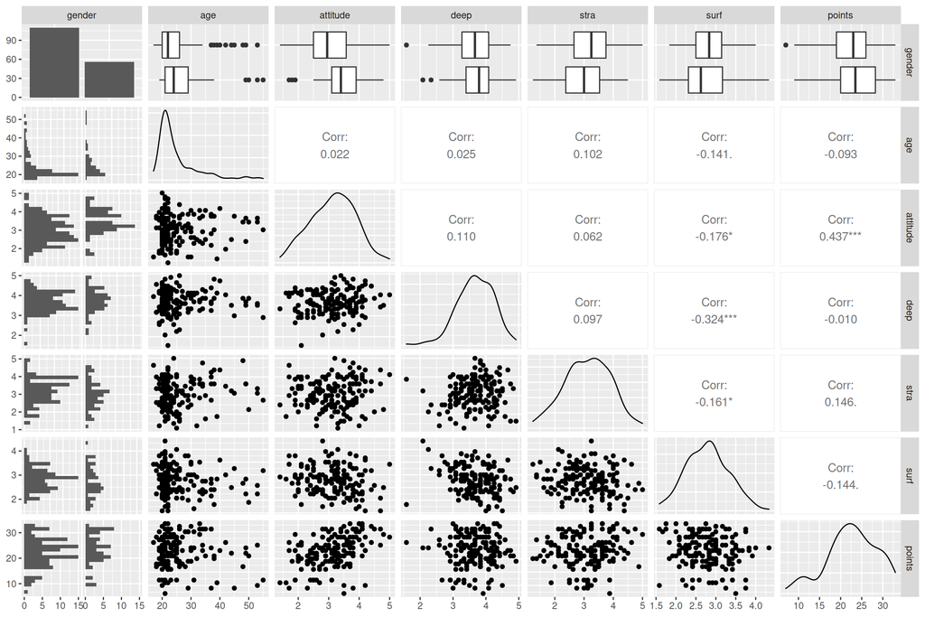

```r
#graphical overview:
p <- ggpairs(analysis_data, mapping = aes(), lower = list(combo = wrap("facethist", bins = 20)))
p
```

```r
summary(analysis_data) #basic summaries of the variables
```

```
##  gender       age           attitude          deep            stra            surf           points
##  F:110   Min.   :17.00   Min.   :1.400   Min.   :1.583   Min.   :1.250   Min.   :1.583   Min.   : 7.00
##  M: 56   1st Qu.:21.00   1st Qu.:2.600   1st Qu.:3.333   1st Qu.:2.625   1st Qu.:2.417   1st Qu.:19.00
##          Median :22.00   Median :3.200   Median :3.667   Median :3.188   Median :2.833   Median :23.00
##          Mean   :25.51   Mean   :3.143   Mean   :3.680   Mean   :3.121   Mean   :2.787   Mean   :22.72
##          3rd Qu.:27.00   3rd Qu.:3.700   3rd Qu.:4.083   3rd Qu.:3.625   3rd Qu.:3.167   3rd Qu.:27.75
##          Max.   :55.00   Max.   :5.000   Max.   :4.917   Max.   :5.000   Max.   :4.333   Max.   :33.00
```

### Linear model

Since age is the variable with the largest p-value, linear model is fitted without it. In this second model the relationship between points and stra remains non-significant so a third model with only attitude as an explanatory variable is fitted. The intercept of the final model is 11.64 and the beta coefficient of attitude is 3.53. The intercept can be interpreted as the expected value of points when attitude equals zero. In addition, the beta coefficient of attitude is the expected increase in points when attitude increases by one unit. The multiple R squared of the final model is 0.19. This means that 19% of the variation in the data is explained by the final model.

```r
my_model <- lm(points ~ attitude+age+stra, data = analysis_data) #model with attitude, age and stra
summary(my_model)
```

```
##
## Call:
## lm(formula = points ~ attitude + age + stra, data = analysis_data)
##
## Residuals:
##      Min       1Q   Median       3Q      Max
## -18.1149  -3.2003   0.3303   3.4129  10.7599
##
## Coefficients:
##             Estimate Std. Error t value Pr(>|t|)
## (Intercept) 10.89543    2.64834   4.114 6.17e-05 ***
## attitude     3.48077    0.56220   6.191 4.72e-09 ***
## age         -0.08822    0.05302  -1.664   0.0981 .
## stra         1.00371    0.53434   1.878   0.0621 .
## ---
## Signif. codes:  0 '***' 0.001 '**' 0.01 '*' 0.05 '.' 0.1 ' ' 1
##
## Residual standard error: 5.26 on 162 degrees of freedom
## Multiple R-squared:  0.2182, Adjusted R-squared:  0.2037
## F-statistic: 15.07 on 3 and 162 DF,  p-value: 1.07e-08
```

```r
my_model2 <- lm(points ~ attitude+stra, data = analysis_data) #model with attitude and stra
summary(my_model2)
```

```
##
## Call:
## lm(formula = points ~ attitude + stra, data = analysis_data)
##
## Residuals:
##      Min       1Q   Median       3Q      Max
## -17.6436  -3.3113   0.5575   3.7928  10.9295
##
## Coefficients:
##             Estimate Std. Error t value Pr(>|t|)
## (Intercept)   8.9729     2.3959   3.745  0.00025 ***
## attitude      3.4658     0.5652   6.132 6.31e-09 ***
## stra          0.9137     0.5345   1.709  0.08927 .
## ---
## Signif. codes:  0 '***' 0.001 '**' 0.01 '*' 0.05 '.' 0.1 ' ' 1
##
## Residual standard error: 5.289 on 163 degrees of freedom
## Multiple R-squared:  0.2048, Adjusted R-squared:  0.1951
## F-statistic: 20.99 on 2 and 163 DF,  p-value: 7.734e-09
```

```r
my_model3 <- lm(points ~ attitude, data = analysis_data) #model with attitude
summary(my_model3)
```

```
##
## Call:
## lm(formula = points ~ attitude, data = analysis_data)
##
## Residuals:
##      Min       1Q   Median       3Q      Max
## -16.9763  -3.2119   0.4339   4.1534  10.6645
##
## Coefficients:
##             Estimate Std. Error t value Pr(>|t|)
## (Intercept)  11.6372     1.8303   6.358 1.95e-09 ***
## attitude      3.5255     0.5674   6.214 4.12e-09 ***
## ---
## Signif. codes:  0 '***' 0.001 '**' 0.01 '*' 0.05 '.' 0.1 ' ' 1
##
## Residual standard error: 5.32 on 164 degrees of freedom
## Multiple R-squared:  0.1906, Adjusted R-squared:  0.1856
## F-statistic: 38.61 on 1 and 164 DF,  p-value: 4.119e-09
```

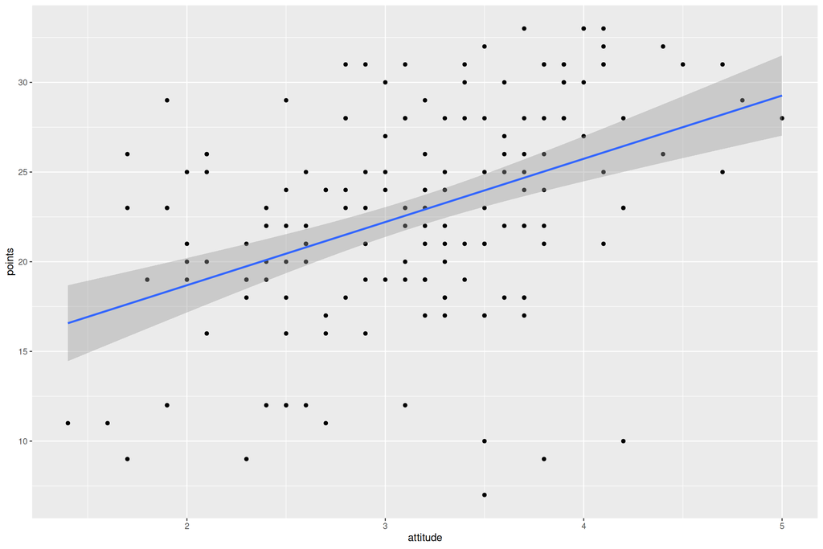

```r
p <- qplot(attitude, points, data = analysis_data) + geom_smooth(method = "lm") #plot
p
```

### Model diagnostic plots

Linear model makes several assumptions. These assumptions include that:

1. The relationship between the target variable and the explanatory variable is linear.
2. The residual errors are normally distributed.
3. The residuals have a constant variance (homoscedasticity).

The validity of these assumptions should be checked when using linear regression. Also, the presence of influential values in the data should be checked.

Residuals vs Leverage plot is used to check whether there are outliers or data points with high leverage. Outliers can be identified by examining the standardized residuals of data points. Cook’s distance measures the influence of the data points as a combination of leverage and residual size. Data points with three largest Cook’s distances are labelled in Residuals vs Leverage plot. There are no points outside the red dashed line so there are no influential data points.

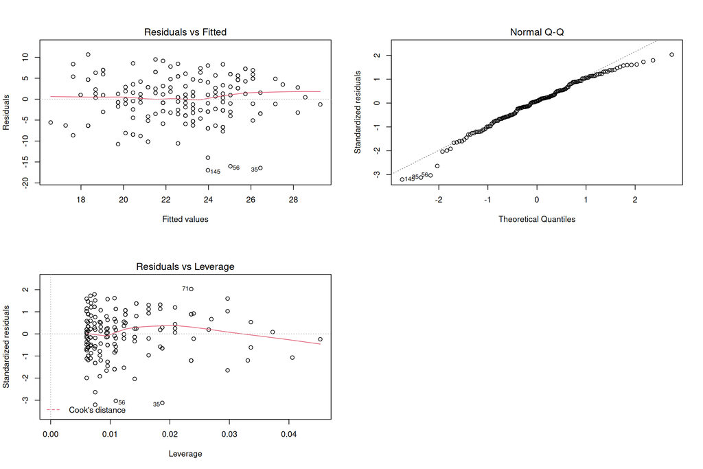

```r
par(mfrow=c(2,2))
plot(my_model3,1)
plot(my_model3,2)
plot(my_model3,5)
```

## 3. Logistic regression

### Data

In this week analysis we use Student performance Data Set which contains information about student performance in mathematics and Portuguese language in secondary education of two Portuguese schools. The data attributes include student grades, demographic, social and school related features, and it was collected by using school reports and questionnaires. The analysis dataset consists of 370 students and 51 variables. The full description of dataset is available in [*here*](https://archive.ics.uci.edu/ml/datasets/Student+Performance).

```r
#reading dataset
pormath <- read.csv(file='/home/jkox/Git/proj/IODS-project/data/pormath.csv')

#names of the variables
names(pormath)
```

```
##  [1] "school"     "sex"        "age"        "address"    "famsize"    "Pstatus"    "Medu"       "Fedu"
##  [9] "Mjob"       "Fjob"       "reason"     "guardian"   "traveltime" "studytime"  "schoolsup"  "famsup"
## [17] "activities" "nursery"    "higher"     "internet"   "romantic"   "famrel"     "freetime"   "goout"
## [25] "Dalc"       "Walc"       "health"     "n"          "id.p"       "id.m"       "failures"   "paid"
## [33] "absences"   "G1"         "G2"         "G3"         "failures.p" "paid.p"     "absences.p" "G1.p"
## [41] "G2.p"       "G3.p"       "failures.m" "paid.m"     "absences.m" "G1.m"       "G2.m"       "G3.m"
## [49] "alc_use"    "high_use"   "cid"
```

```r
dim(pormath) #the dimensions of the dataset
```

```
## [1] 370  51
```

```r
str(pormath) #the structure of the dataset
```

```
## 'data.frame':    370 obs. of  51 variables:
##  $ school    : chr  "GP" "GP" "GP" "GP" ...
##  $ sex       : chr  "F" "F" "F" "F" ...
##  $ age       : int  15 15 15 15 15 15 15 15 15 15 ...
##  $ address   : chr  "R" "R" "R" "R" ...
##  $ famsize   : chr  "GT3" "GT3" "GT3" "GT3" ...
##  $ Pstatus   : chr  "T" "T" "T" "T" ...
##  $ Medu      : int  1 1 2 2 3 3 3 2 3 3 ...
##  $ Fedu      : int  1 1 2 4 3 4 4 2 1 3 ...
##  $ Mjob      : chr  "at_home" "other" "at_home" "services" ...
##  $ Fjob      : chr  "other" "other" "other" "health" ...
##  $ reason    : chr  "home" "reputation" "reputation" "course" ...
##  $ guardian  : chr  "mother" "mother" "mother" "mother" ...
##  $ traveltime: int  2 1 1 1 2 1 2 2 2 1 ...
##  $ studytime : int  4 2 1 3 3 3 3 2 4 4 ...
```

[output cut: 37 more lines]

```r
head(pormath,10) #the first 10 rows of the dataset
```

```
##    school sex age address famsize Pstatus Medu Fedu     Mjob     Fjob     reason guardian traveltime
## 1      GP   F  15       R     GT3       T    1    1  at_home    other       home   mother          2
## 2      GP   F  15       R     GT3       T    1    1    other    other reputation   mother          1
## 3      GP   F  15       R     GT3       T    2    2  at_home    other reputation   mother          1
## 4      GP   F  15       R     GT3       T    2    4 services   health     course   mother          1
## 5      GP   F  15       R     GT3       T    3    3 services services reputation    other          2
## 6      GP   F  15       R     GT3       T    3    4 services   health     course   mother          1
## 7      GP   F  15       R     GT3       T    3    4 services  teacher     course   father          2
## 8      GP   F  15       R     LE3       T    2    2   health services reputation   mother          2
## 9      GP   F  15       R     LE3       T    3    1    other    other reputation   father          2
## 10     GP   F  15       U     GT3       A    3    3    other   health reputation   father          1
##    studytime schoolsup famsup activities nursery higher internet romantic famrel freetime goout Dalc Walc
## 1          4       yes    yes        yes     yes    yes      yes       no      3        1     2    1    1
## 2          2       yes    yes         no      no    yes      yes      yes      3        3     4    2    4
## 3          1       yes    yes        yes     yes    yes       no       no      4        3     1    1    1
```

[output cut: 29 more lines]

### Hypothesis and data exploration

Four interesting variables are selected from the analysis dataset, and the association of those variables with high/low alcohol use (high_use) is examined. The four selected variables are :

- absences (the mean of school absences from classes of mathematics and Portuguese language)
- health (current health status)
- age
- sex

The hypothesis about the association of these variables with alcohol use is that the mean of absences is higher and health status is lower among those with high alcohol use. Furthermore, it is assumed that high alcohol use is more frequent among men than among women, and that age is positively associated with high alcohol use.

There are 111 high alcohol users and 259 low alcohol users in the data. The age range is 15 to 22 years, and there are 195 women and 175 men in the analysis dataset. The mean of absences varies from 0 to 45. When looking the graphical presentation of the pairwise associations between the variables, there seems to be more absences among the high alcohol users. Also, high alcohol users are older than low alcohol users, and the proportion of high alcohol use is higher among men than among women, However, there seems to be no association between high alcohol use and health status. Furthermore, looking the proportions of health status classes by alcohol use, there seems to be no difference,

These findings are in line with the prior hypothesis, except for health status, where a lower health was assumed to be associated with high alcohol use.

```r
summary(subset(pormath, select=c('high_use','absences','health','sex','age')))
```

```
##   high_use          absences          health          sex                 age
##  Mode :logical   Min.   : 0.000   Min.   :1.000   Length:370         Min.   :15.00
##  FALSE:259       1st Qu.: 1.000   1st Qu.:3.000   Class :character   1st Qu.:16.00
##  TRUE :111       Median : 3.000   Median :4.000   Mode  :character   Median :17.00
##                  Mean   : 4.511   Mean   :3.562                      Mean   :16.58
##                  3rd Qu.: 6.000   3rd Qu.:5.000                      3rd Qu.:17.00
##                  Max.   :45.000   Max.   :5.000                      Max.   :22.00
```

```r
table(pormath$sex)
```

```
##
##   F   M
## 195 175
```

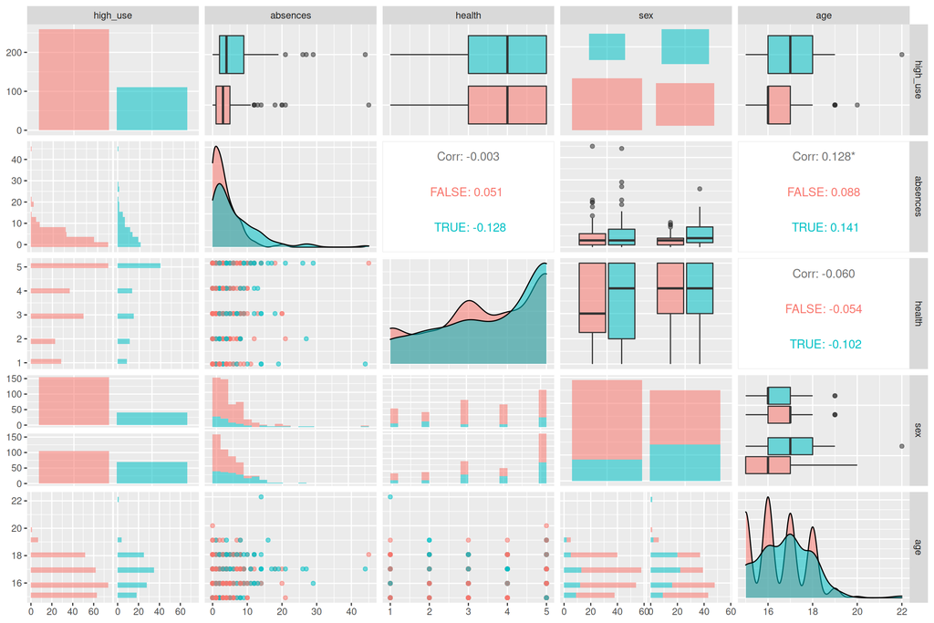

```r
p <- ggpairs(subset(pormath, select=c('high_use','absences','health','sex','age')), mapping = aes(col=high_use,alpha=0.3), lower = list(combo = wrap("facethist", bins = 20)))
p
```

```r
table(pormath$high_use,pormath$health) %>% prop.table(1)
```

```
##
##                 1         2         3         4         5
##   FALSE 0.1351351 0.1081081 0.2355212 0.1737452 0.3474903
##   TRUE  0.0990991 0.1261261 0.1711712 0.1531532 0.4504505
```

### Logistic regression

Logistic regression model was fitted with high alcohol use as target variables and the four selected variables as explanatory variables.

The mean of absences an sex have statistically significant association with high alcohol use. The odds ratio of absences is 1.097 with the interpretation that the expected increase in the odds of being a high alcohol user in 9.7%, for a one-unit increase in absences. Likewise, the expected odds of being a high alcohol user is 2.72 higher for men than for women.

The results indicate that the prior hypothesis concerning absences and sex was correct. However, there is not enough evidence for the hypothesis that older age and lower health were positively associated wth high alcohol use.

```r
m <- glm(high_use ~ absences + health + sex + age, data = pormath, family = "binomial")
summary(m)
```

```
##
## Call:
## glm(formula = high_use ~ absences + health + sex + age, family = "binomial",
##     data = pormath)
##
## Deviance Residuals:
##     Min       1Q   Median       3Q      Max
## -2.3556  -0.8424  -0.6086   1.0700   2.1619
##
## Coefficients:
##             Estimate Std. Error z value Pr(>|z|)
## (Intercept) -4.87786    1.75660  -2.777  0.00549 **
## absences     0.09264    0.02344   3.952 7.75e-05 ***
## health       0.09525    0.08878   1.073  0.28332
## sexM         1.00325    0.24684   4.064 4.82e-05 ***
## age          0.16347    0.10202   1.602  0.10907
## ---
## Signif. codes:  0 '***' 0.001 '**' 0.01 '*' 0.05 '.' 0.1 ' ' 1
##
## (Dispersion parameter for binomial family taken to be 1)
##
##     Null deviance: 452.04  on 369  degrees of freedom
## Residual deviance: 412.11  on 365  degrees of freedom
## AIC: 422.11
##
## Number of Fisher Scoring iterations: 4
```

```r
Coeff <- coef(m) %>% exp
CI <- confint(m) %>% exp
cbind(Coeff,CI)
```

```
##                   Coeff        2.5 %    97.5 %
## (Intercept) 0.007613307 0.0002295193 0.2288702
## absences    1.097072080 1.0500011255 1.1512256
## health      1.099938481 0.9259125849 1.3125241
## sexM        2.727130101 1.6910032352 4.4591635
## age         1.177595137 0.9652572862 1.4414744
```

### Predictions

The model with only absences and sex as explanatory variables is fitted and model performance is evaluated. 91% of the students are predicted as low alcohol users and 9% are predicted as high alcohol users. 68% of students are both low alcohol users and predicted as low alcohol users. The corresponding figure for high alcohol users is 7%. The training error is 25%. This performance is compared to simple guessing strategies: all students are predicted to be low alcohol users and high alcohol users. The performance of these strategies was worse than the training error.

```r
m2 <- glm(high_use ~ absences + sex, data = pormath, family = "binomial")

probabilities <- predict(m2, type = "response")
pormath <- mutate(pormath, probability = probabilities)
pormath <- mutate(pormath, prediction = probability>0.5)

# tabulate the target variable versus the predictions
with(pormath,table(high_use, prediction))
```

```
##         prediction
## high_use FALSE TRUE
##    FALSE   251    8
##    TRUE     86   25
```

```r
# table with proportions
table(high_use = pormath$high_use, prediction = pormath$prediction) %>% prop.table %>% addmargins()
```

```
##         prediction
## high_use      FALSE       TRUE        Sum
##    FALSE 0.67837838 0.02162162 0.70000000
##    TRUE  0.23243243 0.06756757 0.30000000
##    Sum   0.91081081 0.08918919 1.00000000
```

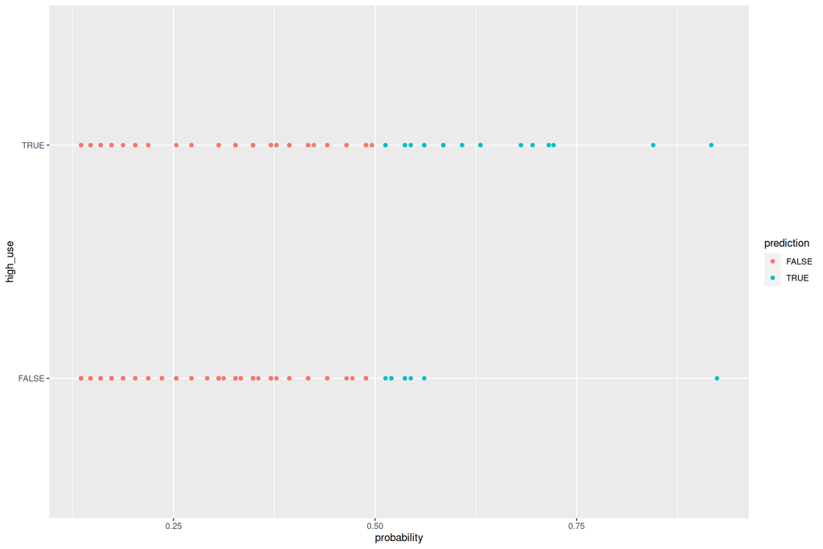

```r
# plot
g <- ggplot(pormath, aes(x = probability, y = high_use, col=prediction)) + geom_point()
g
```

```r
# define a loss function (mean prediction error)
loss_func <- function(class, prob) {
  n_wrong <- abs(class - prob) > 0.5
  mean(n_wrong)
}

#training error:
loss_func(class = pormath$high_use, prob = pormath$probability)
```

```
## [1] 0.2540541
```

```r
#simple guessing strategies:
loss_func(class = pormath$high_use, prob = 0)
```

```
## [1] 0.3
```

```r
loss_func(class = pormath$high_use, prob = 1)
```

```
## [1] 0.7
```

(more chapters to be added similarly as we proceed with the course!)